# Inbred Based Populations

[Statistical Genetics Lab](http://statgen.esalq.usp.br) Department of Genetics Luiz de Queiroz College of Agriculture University of São Paulo

2026-08-10

Starting in version 2.0-0, `OneMap` can also deal with inbred-based populations, that is, populations that have homozygous parental lines in the genealogy (F2s, backcrosses, and RILs). As a consequence, linkage phases do not need to be estimated. Since version 2.3.0, phases are estimated for F2 populations to properly generate progeny haplotypes not only the recombination fraction.

In this vignette, we explain how to proceed with the analysis in an F2 population. The same procedure can be used for backcrosses and RILs as well, and therefore users should not have any difficulty in analyzing their data. However, there are a number of differences from genetic mapping in outcrossing species; please read the proper vignette.

If you are not familiar with `R`, we recommend first the reading of vignette [Introduction to R](https://statgen-esalq.github.io/tutorials/onemap/Introduction_R.html). You do not need to be an expert in R to build your linkage map, but some concepts are necessary and will help you through the process.

There is a GitHub `OneMap` version which is constantly improved, we strongly recommend all users to try [this version](https://github.com/cristianetaniguti/onemap).

# Best practices guidelines for using markers from sequencing data

In [Taniguti et al., 2023](https://academic.oup.com/gigascience/article/doi/10.1093/gigascience/giad092/7330892), we introduced updates to **OneMap 3.0** and evaluated various combinations of bioinformatics tools and filters for obtaining high-quality markers and linkage maps. The paper provides practical guidelines based on these results.

The Reads2Map workflow enables you to replicate these tests on your dataset. This comprehensive pipeline integrates tools such as BWA, GATK, FreeBayes, TASSEL, Stacks, updog, polyRAD, superMASSA, GUSMap, and OneMap to perform read alignment, SNP and genotype calling, and linkage mapping.

Once you have identified the best pipeline for your data—using Reads2Map or another approach—and generated a VCF file, you can follow this tutorial to conduct the analysis on your complete dataset.

# Creating the data file

For F2s, backcrosses, and RILs, two input formats are accepted. The user can choose between the standard `OneMap` file format or the same raw file used by `MAPMAKER/EXP` (Lander et al., 1987). Therefore, one should have no difficulty in using data sets already available for `MAPMAKER/EXP` when deciding to try `OneMap`.

Both types of raw files can contain phenotypic information, but this will not be used during map construction, that requires only genotypic information (made available by molecular markers).

## Creating `MAPMAKER/EXP` data file

The `MAPMAKER/EXP` raw file, combined with the map file produced by `OneMap`, can be readily used for QTL mapping using `R/qtl` (Broman et al., 2008) or `QTL Cartographer` (Wang et al., 2010), among others.

Here, we briefly present how to set up this data file. For more detailed information see the `MAPMAKER/EXP` manual (Lincon et al., 1993), available [here](https://home.cc.umanitoba.ca/~psgendb/birchhomedir/doc/mapmaker/mapmaker.tutorial.pdf).

The first line of your data file should be:

```
data type xxxx
```

where `xxxx` is one of the following data types:

| `xxxx` | Population type |
| --- | --- |
| `f2 backcross` | Backcross |
| `f2 intercross` | F2 |
| `ri self` | RIL, produced by selfing |
| `ri sib` | RIL, produced by sib mating |

The second line should contain the number of individuals in the progeny, the number of markers, and the number of quantitative traits. So, for example, a valid line would be

```
10 5 2
```

for a data set with 10 individuals (yes, very small, but this is just an example), 5 markers, and 2 traits evaluated.

Then, the genotype information is included for each marker. The character `*` indicates the beginning of information of a marker, followed by the marker name. For instance, here is an example of such a file for an F2 population with 10 individuals, 5 markers, and 2 quantitative traits:

```
data type f2 intercross
10 5 2

*M1 A B H H A - B A A B
*M2 C - C C C - - C C A
*M3 D B D D - - B D D B
*M4 C C C - A C C A A C
*M5 C C C C C C C C C C

*weight 10.2 - 9.4 11.3 11.9 8.9 - 11.2 7.8 8.1
*length 1.7 2.1 - 1.8 2.0 1.0 - 1.7 1.0 1.1
```

The codification for genotypes is the following:

| Code | Meaning |
| --- | --- |
| `A` | homozygous for allele A (from parent 1 - AA) |
| `B` | homozygous for allele B (from parent 2 - BB) |
| `H` | heterozygous carrying both alleles (AB) |
| `C` | Not homozygous for allele A (Not AA) |
| `D` | Not homozygous for allele B (Not BB) |
| `-` | Missing data for the individual at this marker |

The `symbols` option (not included in this example), used in `MAPMAKER/EXP` files, is also accepted (please, see its manual for details).

The quantitative trait data should come after the genotypic data and has a similar format, except the trait values for each individual must be separated by at least one space, a tab, or a line break. A dash (`-`) indicates missing data.

This file must be saved in plain text format using a simple text editor such as *notepad* on *Microsoft Windows*. Historically, `MAPMAKER/EXP` uses the `.raw` extension for this file; however, you can use any other extensions, such as `.txt`.

If you want to see more examples about this file type, open `mapmaker_example_bc.raw` and `mapmaker_example_f2.raw`, both available with `OneMap` and saved in the directory `extdata` on your computer, in the folder where you installed `OneMap` (use `system.file(package="onemap")` to see where it is located on your computer).

Now, let us load `OneMap`:

```r
library(onemap)
```

To save your project anytime, type:

```r
save.image("C:/.../yourfile.RData")
```

if you are using Windows, otherwise, adapt the code. Notice that you need to specify where to save and the name of the file. You can also use the toolbar, of course.

## Creating OneMap data file

The `OneMap` data file has few differences compared to MAPMAKER/EXP format. As MAPMAKER/EXP format, the input `OneMap` file is a text file, where the first line indicates the cross-type and the second line provides information about the number of individuals, the number of markers, and the number of quantitative traits. Here, the format also supports keeping physical markers location information. The followed numbers indicate the presence/absence (1/0) of chromosome and position information and the presence/absence(1/0) of phenotypic data.

The third line contains sample IDs. Then, the genotype information is included separately for each marker. The character `*` indicates the beginning of information input for a new marker, followed by the marker name. Next, there is a code indicating the marker type according to:

| Code | Type |
| --- | --- |
| `A.H.B` | Codominant marker |
| `C.A` | Dominant marker for allele B |
| `D.B` | Dominant marker for allele A |
| `A.H` | Marker for backcross |
| `A.B` | Marker for ril self/sib cross |

Finally, after each marker type, comes the genotype data for the segregating population. Missing data are indicated with the character `-` (minus sign) and an empty space separates the information for each individual. Positions and phenotype information, if present, follows genotypic data with a similar structure. Details are found with the help of function `read_onemap`.

Here is an example of such file for 10 individuals, 5 markers (the two zeros in the second line indicate that there is no chromosome information, physical position information), and two phenotypic data, respectively). It is very similar to a MAPMAKER/EXP file, but has additional information about the cross_type.

```
data type f2 intercross
10 5 0 0 2
I1 I2 I3 I4 I5 I6 I7 I8 I9 I10
*M1 A.H.B  ab a - ab b a ab - ab b
*M2 A.H.B  a - ab ab - b a - a ab
*M3 C.A    c a a c c - a c a c
*M4 A.H.B  ab b - ab a b ab b - a
*M5 D.B    b b d - b d b b b d
*fen1 10.3 11.2 11.1 - 9.8 8.9 11.0 10.7 - 10.1
*fen2 42 49 - 45 51 42 28 32 38 40
```

In case you have physical chromosome and position information:

```
data type f2 intercross
10 5 1 1 2
I1 I2 I3 I4 I5 I6 I7 I8 I9 I10
*M1 A.H.B  ab a - ab b a ab - ab b
*M2 A.H.B  a - ab ab - b a - a ab
*M3 C.A    c a a c c - a c a c
*M4 A.H.B  ab b - ab a b ab b - a
*M5 D.B    b b d - b d b b b d
*CHROM    1 1 1 2 2
*POS    2391 3812 5281 1823 3848
*fen1 10.3 11.2 11.1 - 9.8 8.9 11.0 10.7 - 10.1
*fen2 42 49 - 45 51 42 28 32 38 40
```

The input file must be saved in text format, with extensions like `.raw`. It is a good idea to open the text files called `onemap_example_f2.raw`, `onemap_example_bc`, `onemap_example_riself` (available in `extdata` with `OneMap` and saved in the directory you installed it) to see how this file should be. You can see where `OneMap` is installed using the command `system.file(package="onemap")`.

# Importing data

## From `MAPMAKER/EXP` file

Once you created your data file with raw data, you can use `OneMap` function `read_mapmaker` to import it to `OneMap`:

```r
mapmaker_example_f2 <- read_mapmaker(dir="C:/workingdirectory",
                                     file="your_data_file.raw")
```

The first argument is the directory where the input file is located, modify it accordingly. The second one is the data file name.

In this example, an object named `mapmaker_example_f2.raw` was created. Notice that if you leave the argument `dir` blank, the file will be read from your current *working directory*. To set a working directory, see [Introduction to R (Importing and Exporting Data)](https://statgen-esalq.github.io/tutorials/onemap/Introduction_R.html).

```r
mapmaker_example_f2 <- read_mapmaker(file= system.file("extdata/mapmaker_example_f2.raw",
                                                       package = "onemap"))
```

For this example, we will use a simulated data set from an F2 population which is distributed along with `OneMap`. Because this particular data set is distributed along with the package, you can load it by typing:

```r
data("mapmaker_example_f2")
```

To see what this data set is about, type:

```r
mapmaker_example_f2
```

```
#>   This is an object of class 'onemap'
#>     Type of cross:      f2
#>     No. individuals:    200
#>     No. markers:        66
#>     CHROM information:  no
#>     POS information:    no
#>     Percent genotyped:  85
#>
#>     Segregation types:
#>        AA : AB : BB -->  36
#>         Not AA : AA -->  15
#>         Not BB : BB -->  15
#>
#>     No. traits:         1
#>     Missing trait values:
#>   Trait_1: 0
```

As you can see, the data consists of a sample of 200 individuals genotyped for 66 markers (36 co-dominant (`AA`, `AB` or `BB`), 15 dominant in one parent (`Not AA` or `AA`) and 15 dominant in the other parent (`Not BB` or `BB`) with 15% of missing data. You can also see that there is phenotypic information for one trait in the data set, that can be used for QTL mapping.

## From `OneMap` raw file

The same procedure is made for the `OneMap` raw file, but, instead of using the function `read_mapmaker` we use `read_onemap` to read the `OneMap` format.

```r
onemap_example_f2 <- read_onemap(dir="C:/workingdirectory",
                                 inputfile = "your_data_file.raw")
```

In this example, an object named `onemap_example_f2.raw` was created. The data set containing the same markers and individuals of the `mapmaker_example_f2.raw` file. Would be a good idea to open these two files in a text editor and compare them to better understand the differences between the two kinds of input files. We can read the `onemap_example_f2.raw` using:

```r
onemap_example_f2 <- read_onemap(inputfile= system.file("extdata/onemap_example_f2.raw",
                                                        package = "onemap"))
```

Or, because this particular data are available together with the `OneMap` package:

```r
data("onemap_example_f2")
```

To see what this data set is about, type:

```r
onemap_example_f2
```

```
#>   This is an object of class 'onemap'
#>     Type of cross:      f2
#>     No. individuals:    200
#>     No. markers:        66
#>     CHROM information:  no
#>     POS information:    no
#>     Percent genotyped:  85
#>
#>     Segregation types:
#>        AA : AB : BB -->  36
#>         Not AA : AA -->  15
#>         Not BB : BB -->  15
#>
#>     No. traits:         1
#>     Missing trait values:
#>   Trait_1: 0
```

## Importing data from the `VCF` file

If you are working with biallelic markers, as SNPs and indels (only codominant markers A.H.B), in VCF (Variant Call Format) files, you can import information from `VCF` to `OneMap` using `onemap_read_vcfR` function.

With the `onemap_read_vcfR` you can convert VCF file directly to `onemap`. The `onemap_read_vcfR` function keeps chromosome and position information for each marker at the end of the raw file.

We will use the same example file `vcf_example_f2.vcf` to show how it works.

Here we use the the `vcfR` package internally to help this conversion. The `vcfR` authors mentioned in their [tutorials](https://knausb.github.io/vcfR_documentation/index.html) that RAM memory use is an important consideration when using the package. Depending of your dataset, the object created can be huge and occupy a lot of memory.

You can use `onemap_read_vcfR` function to convert the VCF file to `onemap` object. The parameters used are the `vcf` with the VCF file path, the identification of each parent (here, you must define only one sample for each parent) and the cross type.

```r
vcf_example_f2 <- onemap_read_vcfR(vcf = system.file("extdata/vcf_example_f2.vcf.gz", package = "onemap"),
                                   parent1 = "P1",
                                   parent2 = "P2",
                                   cross = "f2 intercross")
```

Depending on your dataset, this function can take some time to run.

**NOTE**: From version 2.0.6 to 2.1.1005, `OneMap` had the `vcf2raw` function to convert `vcf` to `.raw`. Now, this function is defunct, but it can be replaced by a combination of `onemap_read_vcfR` and `write_onemap_raw` functions. See Exporting .raw file from onemap object session to further information about `write_onemap_raw`.

# Visualization of raw data

Before building your linkage map, you should take a look at your data set. First, notice that by reading the raw data into `OneMap`, an object of classes `onemap` and `f2` was produced:

```r
class(onemap_example_f2)
```

```
#> [1] "onemap" "f2"
```

```r
class(vcf_example_f2)
```

```
#>               f2 intercross
#>      "onemap"          "f2"
```

In fact, functions `read_mapmaker` and `read_onemap` will produce objects of classes `backcross`, `riself`, `risib` or `f2`, according to the information in the data file for inbred-based populations. Therefore, you can use `OneMap`’s version of function `plot` to produce a graphic with information about the raw data. It will automatically recognize the class of the object and produce the graphic. To see it in action, try:

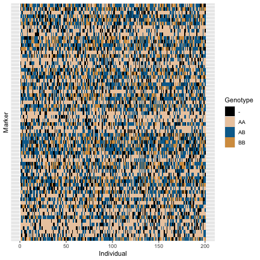

```r
plot(onemap_example_f2)
```

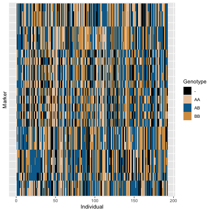

```r
plot(vcf_example_f2)
```

The graphic is self-explanatory. If you want to save it, see the help for function `plot.onemap`:

```r
?plot.onemap
```

This graphic shows that missing data is somehow randomly distributed; also, the proportion of dominant markers is relatively high for this data set. In `OneMap`’s notation, codominant markers are classified as of B type; dominant ones, by C type (for details about this notation, see the vignette for outcrossing species). You can see the number of loci within each type using function `plot_by_segreg_type`:

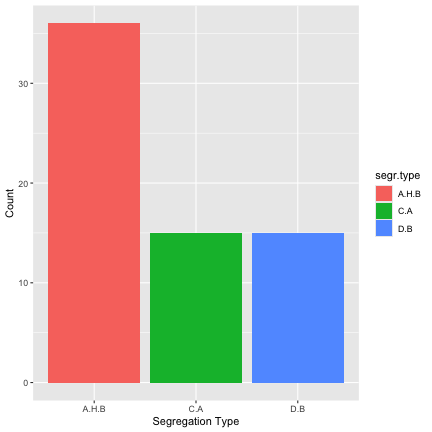

```r
plot_by_segreg_type(onemap_example_f2)
```

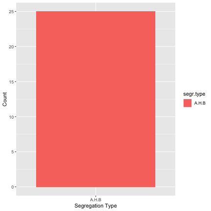

```r
plot_by_segreg_type(vcf_example_f2)
```

So, as shown before, the object `onemap_example_f2` has 36 codominant markers and 30 dominant ones and the `vcf_example_f2`has only codominant markers.

## Graphical view of genotypes and allele depths

Function `create_depth_profile` generates dispersion graphics with x and y axis representing, respectively, the reference and alternative allele depths. The function is only available for biallelic markers in VCF files with allele counts information. Each dot represents a genotype for `mks` markers and `inds` individuals. If both arguments receive `NULL`, all markers and individuals are considered. Dots are colored according to the genotypes present in the `OneMap` object (`GTfrom = onemap`) or in the VCF file (`GTfrom = vcf`). An rds file is generated with the data in the graphic (`rds.file`). The `alpha` argument controls the transparency of the color of each dot. Control this parameter is a good idea when having a big amount of markers and individuals. The `x_lim` and `y_lim` control the axis scale limits, by default, it uses the maximum value of the counts.

Here is an example of the simulated dataset.

```r
simu_f2_obj <- onemap_read_vcfR(vcf = system.file("extdata/vcf_example_f2.vcf.gz", package="onemap"),
                                cross = "f2 intercross",
                                parent1 = "P1", parent2 = "P2")
```

```
#> 1 Markers were removed from the dataset because one or both of the parents are heterozygotes, we do not expect heterozygotes parents in F2 populations.
```

```r
library(vcfR)
vcfR_object <- read.vcfR(system.file("extdata/vcf_example_f2.vcf.gz", package="onemap"))
```

```
#> Scanning file to determine attributes.
#> File attributes:
#>   meta lines: 8
#>   header_line: 9
#>   variant count: 26
#>   column count: 203
#> Meta line 8 read in.
#> All meta lines processed.
#> gt matrix initialized.
#> Character matrix gt created.
#>   Character matrix gt rows: 26
#>   Character matrix gt cols: 203
#>   skip: 0
#>   nrows: 26
#>   row_num: 0
#> Processed variant: 26
#> All variants processed
```

```r
create_depths_profile(onemap.obj = simu_f2_obj,
                      vcfR.object =  vcfR_object,
                      parent1 = "P1",
                      parent2 = "P2",
                      vcf.par = "AD",
                      recovering = FALSE,
                      mks = NULL,
                      inds = NULL,
                      GTfrom = "vcf",
                      alpha = 0.1,
                      rds.file = "depths_f2.rds")
```

Selecting genotypes from `vcf` (GTfrom = “vcf”) the colors are separated by VCF genotypes: `0/0` homozygote for the reference allele, `0/1` heterozygote, and `1/1` homozygote for the alternative allele. Depending on your VCF, you can also have phased genotypes, which are presented by pipe (|) instead of the bar (/).

## Set genotypes probabilities (new!)

By default, `OneMap` sets a error probability of $10^{-5}$ for every genotype:

```r
head(simu_f2_obj$error)
```

```
#>              [,1]         [,2]         [,3]         [,4]
#> SNP1_IND1 0.00001 9.999900e-01 9.999900e-01 1.000000e-05
#> SNP2_IND1 0.00001 9.999900e-01 9.999900e-01 1.000000e-05
#> SNP3_IND1 1.00000 1.000000e+00 1.000000e+00 1.000000e+00
#> SNP5_IND1 0.99999 3.333333e-06 3.333333e-06 3.333333e-06
#> SNP6_IND1 0.99999 3.333333e-06 3.333333e-06 3.333333e-06
#> SNP7_IND1 0.99999 3.333333e-06 3.333333e-06 3.333333e-06
```

See [Taniguti et. al, 2023](https://academic.oup.com/gigascience/article/doi/10.1093/gigascience/giad092/7330892) Supplementary File 1 for details about the `$error` object format.

For markers from sequencing technology, this value is unrealistic and generates inflated linkage maps. `OneMap` 3.0 can consider three types of genotype probabilities to consider error in the HMM chain. A single global value (global_error), a matrix with dimensions (number of individuals) x (number of markers) with genotypes errors values (genotypes_errors), and a matrix with dimensions (number of individuals)*(number of markers) x possible genotypes (genotypes_probs). See details in the function `create_probs`:

```r
?create_probs
```

If you have a VCF file, you can use the function `extract_depth` to obtain the genotypes_errors and genotypes_probs from the GQ or PL or GL format field:

```r
genotypes_errors <- extract_depth(vcfR.object = vcfR_object,
                                  onemap.object=simu_f2_obj,
                                  vcf.par= "GQ",
                                  parent1="P1",
                                  parent2="P2",
                                  recovering=FALSE)

genotypes_errors[10:50, 1:5]
```

```
#>               SNP1         SNP2         SNP3         SNP5         SNP6
#> IND12 2.511886e-10 1.584893e-10 2.511886e-10 1.258925e-10 1.258925e-10
#> IND13           NA           NA 1.258925e-10           NA           NA
#> IND14 1.258925e-10 1.258925e-10 1.258925e-10 1.258925e-10 1.258925e-10
#> IND15 1.258925e-10 1.258925e-10 2.511886e-10 3.981072e-10 1.258925e-10
#> IND16 3.981072e-10 2.511886e-10           NA 2.511886e-10 1.584893e-10
#> IND17 1.584893e-10 1.258925e-10 1.258925e-10 1.258925e-10 1.584893e-10
#> IND18 1.258925e-10 1.258925e-10 1.584893e-10 1.584893e-10 1.584893e-10
#> IND19 1.258925e-10 1.584893e-10 1.258925e-10 1.584893e-09 1.258925e-10
#> IND20 2.511886e-10 1.584893e-10 1.258925e-10 1.258925e-10 1.258925e-10
#> IND21 2.511886e-10 3.981072e-10 1.258925e-10 2.511886e-10 1.258925e-10
#> IND22 1.584893e-09 3.981072e-10 1.258925e-10 1.258925e-10 1.258925e-10
#> IND23 1.584893e-10 3.981072e-10 1.258925e-10 1.258925e-10 1.258925e-10
#> IND25 1.258925e-10 1.258925e-10 1.584893e-10 1.258925e-10 1.258925e-10
#> IND26 3.981072e-10 1.258925e-08 1.258925e-10 1.258925e-10 1.258925e-10
#> IND27           NA           NA 1.258925e-10 1.258925e-10 3.981072e-10
#> IND28 1.258925e-10 1.258925e-10 1.258925e-10 1.258925e-10 1.258925e-10
#> IND30           NA 1.584893e-10 1.258925e-10 1.258925e-10 1.258925e-10
#> IND31 1.258925e-10 1.258925e-10           NA 1.258925e-10 1.258925e-10
#> IND32 1.258925e-10 1.584893e-09           NA 1.258925e-10 1.258925e-10
#> IND33 1.258925e-10 2.511886e-10 1.258925e-10 1.258925e-10 1.258925e-10
#> IND34 3.981072e-10 1.584893e-09 1.258925e-10 1.258925e-10 1.258925e-10
#> IND35 1.258925e-10 1.258925e-10           NA 1.258925e-10 1.258925e-10
#> IND36           NA           NA 1.258925e-10           NA           NA
#> IND37 1.258925e-10 1.258925e-10           NA 1.258925e-10 1.258925e-10
#> IND38 3.981072e-10 1.258925e-10 1.258925e-10 2.511886e-10 1.584893e-10
#> IND39 1.258925e-10 2.511886e-10 3.981072e-10 1.584893e-10 1.584893e-09
#> IND40 1.258925e-10 1.258925e-10 1.258925e-10           NA           NA
#> IND42 1.584893e-10 1.258925e-10 1.258925e-10 3.981072e-10 2.511886e-10
#> IND43           NA           NA 1.258925e-10 3.981072e-10 2.511886e-10
#> IND44 1.584893e-10 3.981072e-10 1.584893e-09 1.584893e-09 1.258925e-10
#> IND45 1.258925e-10 1.258925e-10           NA 1.258925e-10 1.258925e-10
#> IND46 2.511886e-10 1.258925e-10 1.258925e-10 1.258925e-10 1.258925e-10
#> IND47           NA           NA 2.511886e-10 1.584893e-09 1.584893e-10
#> IND48 1.258925e-10 1.258925e-10 1.258925e-10           NA           NA
#> IND49 1.258925e-10 1.258925e-10           NA 1.258925e-10 3.981072e-10
#> IND50           NA           NA 1.258925e-10           NA 3.981072e-10
#> IND51           NA           NA 1.584893e-09 3.981072e-10 2.511886e-10
#> IND52 3.981072e-10 1.584893e-10 2.511886e-10 1.258925e-10 1.258925e-10
#> IND53 2.511886e-10 1.258925e-10 1.258925e-10 1.258925e-10 1.258925e-10
#> IND54 1.258925e-10 1.258925e-10 1.258925e-10 1.258925e-10 1.258925e-10
#> IND55 1.258925e-08 2.511886e-10 1.258925e-10           NA 1.258925e-08
```

```r
onemap_obj_errors <- create_probs(simu_f2_obj, genotypes_errors = genotypes_errors)
head(onemap_obj_errors$error)
```

```
#>                   [,1]         [,2]         [,3]         [,4]
#> SNP1_IND1 1.258925e-10 1.000000e+00 1.000000e+00 1.258925e-10
#> SNP2_IND1 1.258925e-10 1.000000e+00 1.000000e+00 1.258925e-10
#> SNP3_IND1 1.000000e+00 1.000000e+00 1.000000e+00 1.000000e+00
#> SNP5_IND1 1.000000e+00 5.282977e-11 5.282977e-11 5.282977e-11
#> SNP6_IND1 1.000000e+00 1.327024e-10 1.327024e-10 1.327024e-10
#> SNP7_IND1 1.000000e+00 5.282977e-11 5.282977e-11 5.282977e-11
```

```r
genotypes_probs <- extract_depth(vcfR_object,
                                 simu_f2_obj,
                                 vcf.par = "PL",
                                 parent1 = "P1",
                                 parent2 = "P2")

genotypes_probs[1:5, ]
```

```
#>                   [,1]       [,2]         [,3]
#> SNP1_IND1 7.943282e-12 1.00000000 1.258925e-22
#> SNP2_IND1 3.981072e-15 1.00000000 2.511886e-22
#> SNP3_IND1 1.000000e+00 1.00000000 1.000000e+00
#> SNP5_IND1 9.843983e-01 0.01560166 2.472697e-22
#> SNP6_IND1 9.406491e-01 0.05935094 3.744791e-15
```

```r
onemap_obj_probs <- create_probs(simu_f2_obj, genotypes_probs = genotypes_probs)
head(onemap_obj_probs$error)
```

```
#>                   [,1]       [,2]       [,3]         [,4]
#> SNP1_IND1 7.943282e-12 1.00000000 1.00000000 1.258925e-22
#> SNP2_IND1 3.981072e-15 1.00000000 1.00000000 2.511886e-22
#> SNP3_IND1 1.000000e+00 1.00000000 1.00000000 1.000000e+00
#> SNP5_IND1 9.843983e-01 0.01560166 0.01560166 2.472697e-22
#> SNP6_IND1 9.406491e-01 0.05935094 0.05935094 3.744791e-15
#> SNP7_IND1 9.843983e-01 0.01560166 0.01560166 2.472697e-22
```

According to results from Reads2Map using a global error rate can be the best solution in most cases. However, the software probabilities are useful to filter markers before starting the linkage map building:

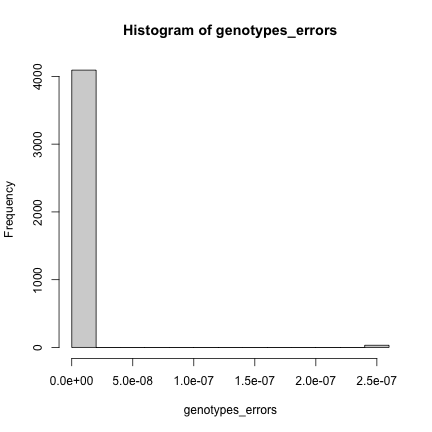

```r
hist(genotypes_errors) # Check distribution to define threshold - it will change according to the software used for genotype calling
```

```r
summary(as.vector(genotypes_errors))
```

```
#>    Min. 1st Qu.  Median    Mean 3rd Qu.    Max.    NA's
#>       0       0       0       0       0       0     676
```

```r
onemap_obj_prob_filt <- filter_prob(onemap_obj_probs, threshold = 0.9)
```

```
#> 296 genotypes were converted to missing data.
```

Now, we can set the genotype probabilities according to the selected global error:

```r
onemap_obj_global_err <- create_probs(onemap_obj_prob_filt, global_error = 0.075)
```

Note: This section is included solely to demonstrate the possibility of adjusting the error probability. This adjustment is not applied in subsequent steps of this tutorial.

## Read multiallelic markers from VCF (new!)

If you have multiallelic markers (MNPs) in your VCF file, set the `only_biallelics` to `FALSE`. Here, we have the multiallelic markers in a separated file:

```r
onemap_obj_multi <- onemap_read_vcfR("roses_populations.haps.new.names.vcf", parent1 = "PH", parent2 = "J14-3", cross = "outcross", only_biallelic = FALSE) # Example data not available

onemap_obj_multi
```

```
6659 Markers were removed of the dataset because one or both of parents have no informed genotypes (are missing data)
8351 Markers were removed from the dataset because both of parents are homozygotes, these markers are considered non-informative in outcrossing populations.

This is an object of class 'onemap'
Type of cross:      outcross
No. individuals:    138
No. markers:        7991
CHROM information:  yes
POS information:    yes
Percent genotyped:  81

Segregation types:
A.1 -->  830
A.2 -->  1891
B3.7 -->  548
D1.10 -->  1949
D1.9 -->  673
D2.14 -->  641
D2.15 -->  1459

No. traits:         0
```

This one does not have genotype probabilities information and erroneous multiallelic markers can generate higher impact in the map quality. Therefore, we will use a global error rate of 0.1 for them (value also defined using Reads2Map workflows):

```r
onemap_obj_multi <- create_probs(onemap_obj_multi, global_error = 0.1)
```

# Combining `OneMap` objects

If you have more than one dataset of markers, all from the same cross-type, you can use the function `combine_onemap` to merge them into only one `onemap` object.

In our example, we have two `onemap` objects:

- first: `onemap_example_f2` (equivalent to `mapmaker_example_f2`) with 66 markers and 200 individuals
- second: `vcf_example_f2` with 25 biallelic markers and 192 individuals.

The `combine_function` recognizes the correspondent individuals by the ID, thus, it is important to define exactly the same IDs to respective individuals in both `raw` files. Compared with the first file, the second file does not have markers information for 8 individuals. The `combine_onemap` will complete that information with NA.

In our examples, we have only genotypic information, but the function can also merge the phenotypic information if it exists.

```r
comb_example <- combine_onemap(onemap_example_f2, vcf_example_f2)
comb_example
```

```
#>   This is an object of class 'onemap'
#>     Type of cross:      f2
#>     No. individuals:    200
#>     No. markers:        91
#>     CHROM information:  yes
#>     POS information:    yes
#>     Percent genotyped:  84
#>
#>     Segregation types:
#>        AA : AB : BB -->  61
#>         Not AA : AA -->  15
#>         Not BB : BB -->  15
#>
#>     No. traits:         1
#>     Missing trait values:
#>   Trait_1: 0
```

The function arguments are the names of the `OneMap` objects you want to combine.

Plotting markers genotypes from the outputted `OneMap` object, we can see that there are more missing data `-` (black vertical lines) for some individuals because they were missing in the second file.

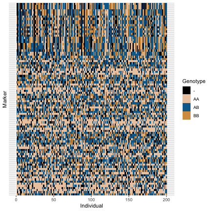

```r
plot(comb_example)
```

# Find redundant markers

It is possible that there are redundant markers in your dataset, especially when dealing with too many markers. Redundant markers have the same genotypic information that others markers, usually because didn’t happen recombination events between each other. They will not increase information on the map but will increase computational effort during the map building. Therefore, it is a good practice to remove them to build the map and, once the map is already built, they can be added again.

First, we use the function `find_bins` to group the markers into bins according to their genotypic information. In other words, markers with the same genotypic information will be in the same bin.

```r
bins <- find_bins(comb_example, exact = FALSE)
bins
```

```
#> This is an object of class 'onemap_bin'
#>     No. individuals:                         200
#>     No. markers in original dataset:         91
#>     No. of bins found:                       90
#>     Average of markers per bin:              1.011111
#>     Type of search performed:                non exact
```

The first argument is the `OneMap` object and the `exact` argument specifies if only markers with exact same information will be at the same bin. Using `FALSE` at this second argument, missing data will not be considered and the marker with the lowest amount of missing data will be the representative marker on the bin.

```r
bins_example <- create_data_bins(comb_example, bins)
bins_example
```

```
#>   This is an object of class 'onemap'
#>     Type of cross:      f2
#>     No. individuals:    200
#>     No. markers:        90
#>     CHROM information:  yes
#>     POS information:    yes
#>     Percent genotyped:  84
#>
#>     Segregation types:
#>        AA : AB : BB -->  60
#>         Not AA : AA -->  15
#>         Not BB : BB -->  15
#>
#>     No. traits:         1
#>     Missing trait values:
#>   Trait_1: 0
```

The arguments for `create_data_bins` function are the `OneMap` object and the object created by `find_bins` function.

# Exporting .raw file from `OneMap` object

The functions `onemap_read_vcfR` generates new `OneMap` objects without use a input `.raw` file. Also, the function `combine_onemap` manipulates the information of the original `.raw` file and creates a new data set. In both cases, you do not have an input file `.raw` that contains the same information as your current onemap object If you want to create a new input file with the data set you are working on after using these functions, you can use the function `write_onemap_raw`.

```r
write_onemap_raw(bins_example, file.name = "new_dataset.raw", cross="f2 intercross")
```

The file `new_dataset.raw` will be generated in your working directory. In our example, it contains markers from `onemap_example_f2` and `vcf_example_f2` data sets.

# Segregation tests

Now, it should be interesting to see if markers are segregating following what is expected by Mendel’s law. You first need to use function `test_segregation` using as argument an object of class `onemap`.

```r
f2_test <- test_segregation(bins_example)
```

This will produce an object of class `onemap_segreg_test`:

```r
class(f2_test)
```

```
#> [1] "onemap_segreg_test"
```

You cannot see the results if you simply type the object name; use `OneMap`’s version of the `print` function for objects of class `onemap_segreg_test`:

```r
f2_test
```

(Nothing is shown!)

```r
print(f2_test)
```

```
#>    Marker    H0  Chi-square     p-value % genot.
#> 1      M1 1:2:1 0.206896552 0.901722662     87.0
#> 2      M2   3:1 0.292682927 0.588506355     82.0
#> 3      M3   3:1 0.124031008 0.724703003     86.0
#> 4      M4   3:1 0.292682927 0.588506355     82.0
#> 5      M5   3:1 0.159763314 0.689374522     84.5
#> 6      M6   3:1 0.620689655 0.430791121     87.0
#> 7      M7 1:2:1 3.185185185 0.203397600     81.0
#> 8      M8   3:1 0.165644172 0.684012345     81.5
#> 9      M9   3:1 0.126984127 0.721579725     84.0
#> 10    M10 1:2:1 1.721893491 0.422761645     84.5
#> 11    M11   3:1 1.390946502 0.238245323     81.0
#> 12    M12 1:2:1 1.678160920 0.432107681     87.0
#> 13    M13   3:1 0.154285714 0.694472964     87.5
#> 14    M14 1:2:1 5.337209302 0.069348924     86.0
```

[output cut: 76 more lines]

This shows the results of the Chi-square test for the expected Mendelian segregation pattern of each marker locus. This depends of course on the marker type, because codominant markers can show heterozygous genotypes. The appropriate null hypothesis is selected by the function. The proportion of individuals genotyped is also shown.

To declare statistical significance, remember that you should consider that multiple tests are being performed. To guide you in the analysis, function `Bonferroni_alpha` shows the alpha value that should be considered for this number of loci if applying Bonferroni’s correction with global alpha of 0.05:

```r
Bonferroni_alpha(f2_test)
```

```
#> [1] 0.0005555556
```

You can subset object `f2_test` to see which markers are distorted under Bonferroni’s criterion, but it is easier to see the proportion of markers that are distorted by drawing a graphic using `OneMap`’s version of the function `plot` for objects of class `onemap_segreg_test`:

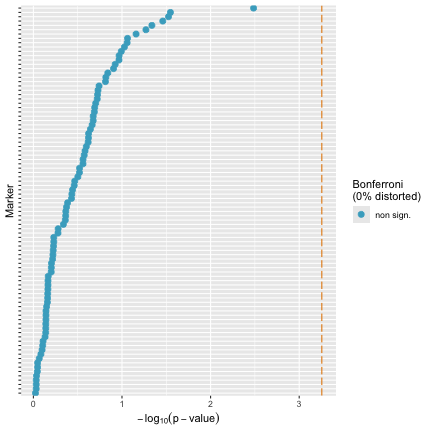

```r
plot(f2_test)
```

The graphic is self-explanatory: *p*-values were transformed by using `-log10(p-values)` for better visualization. A vertical line shows the threshold for tests if Bonferroni’s correction is applied. Significant and non-significant tests are identified. In this particular example, no test was statistically significant, so none will be discarded.

Please, remember that Bonferroni’s correction is **conservative**, and also that discarding marker data might not be a good approach to your analysis. This graphic is just to suggest a criterion, so use it with caution.

You can see a list of markers with non-distorted segregation using function `select_segreg`:

```r
select_segreg(f2_test)
```

```
#>  [1] "M1"    "M2"    "M3"    "M4"    "M5"    "M6"    "M7"    "M8"    "M9"
#> [10] "M10"   "M11"   "M12"   "M13"   "M14"   "M15"   "M16"   "M17"   "M18"
#> [19] "M19"   "M20"   "M21"   "M22"   "M23"   "M24"   "M25"   "M26"   "M27"
#> [28] "M28"   "M29"   "M30"   "M31"   "M32"   "M33"   "M34"   "M35"   "M36"
#> [37] "M37"   "M38"   "M39"   "M40"   "M41"   "M42"   "M43"   "M44"   "M45"
#> [46] "M46"   "M47"   "M48"   "M49"   "M50"   "M51"   "M52"   "M53"   "M54"
#> [55] "M55"   "M56"   "M57"   "M58"   "M59"   "M60"   "M61"   "M62"   "M63"
#> [64] "M64"   "M65"   "M66"   "SNP1"  "SNP2"  "SNP3"  "SNP5"  "SNP6"  "SNP7"
#> [73] "SNP8"  "SNP9"  "SNP10" "SNP11" "SNP12" "SNP13" "SNP14" "SNP15" "SNP16"
#> [82] "SNP17" "SNP18" "SNP19" "SNP20" "SNP21" "SNP22" "SNP23" "SNP24" "SNP26"
```

To get a list of distorted ones (none in this example):

```r
select_segreg(f2_test, distorted = TRUE)
```

```
#> character(0)
```

It is not recommended, but you can define a different threshold value by changing the `threshold` argument of the function `select_segreg`.

For the next steps will be useful to know the numbers of each marker with segregation distortion, so then you can keep those out of your map building analysis. These numbers refer to the lines where markers are located on the data file.

To access the corresponding number for of these markers you can change the `numbers` argument:

```r
no_dist <- select_segreg(f2_test, distorted = FALSE, numbers = TRUE) #to show the markers numbers without segregation distortion
no_dist
```

```
#>  [1]  1  2  3  4  5  6  7  8  9 10 11 12 13 14 15 16 17 18 19 20 21 22 23 24 25
#> [26] 26 27 28 29 30 31 32 33 34 35 36 37 38 39 40 41 42 43 44 45 46 47 48 49 50
#> [51] 51 52 53 54 55 56 57 58 59 60 61 62 63 64 65 66 67 68 69 70 71 72 73 74 75
#> [76] 76 77 78 79 80 81 82 83 84 85 86 87 88 89 90
```

```r
dist <- select_segreg(f2_test, distorted = TRUE, numbers = TRUE) #to show the markers numbers with segregation distortion
dist
```

```
#> integer(0)
```

# Estimating two-point recombination fractions

After visualizing raw data and checking for segregation distortion, let us now estimate recombination fractions between all pairs of markers (two-point tests). This is necessary to allow us to test which markers are linked. At this point, you should pay no attention if markers show segregation distortion or not, that is, simply use all of them.

```r
twopts_f2 <- rf_2pts(input.obj = bins_example)
```

There are two optional arguments in function `rf_2pts`: `LOD` and `max.rf` which indicate the minimum LOD Score and the maximum recombination fraction to declare linkage (they default to 3.0 and 0.5, respectively).

The default for the recombination fraction is easy to understand, because if `max.rf < 0.5` we could state that markers are linked. The LOD Score is the statistic used to evaluate the significance of the test for `max.rf = 0.50`. This needs to take into consideration the number of tests performed, which of course depends on the number of markers. Function `suggest_lod` can help users to find an initial value to use for their linkage test. For this example:

```r
(LOD_sug <- suggest_lod(bins_example))
```

```
#> [1] 4.145858
```

Thus, one should consider using `LOD = 4.145858` for the tests. Please, notice that this is just a guide, not a value to take without any further consideration. For now, we will keep the default values, but later will show that results do not change in our example by using `LOD = 3` or `LOD = 4.145858`.

If you want to see the results for a single pair of markers, say `M12` and `M42`, use:

```r
print(twopts_f2, c("M12", "M42"))
```

```
#>   Results of the 2-point analysis for markers: M12 and M42
#>   Criteria: LOD =  3 , Maximum recombination fraction =  0.5
#>
#>           rf        LOD
#> CC 0.6424445 1.94309400
#> CR 0.3932846 0.02307756
#> RC 0.3932846 0.02307756
#> RR 0.3575555 1.94309400
```

Since version 2.3.0, we estimate phases for F2 populations too, so here you can see the recombination fractions and LOD values for each possible phase. For RILs and backcross, you will obtain only one value.

This was possible because `OneMap` has a version of the `print` function that can be applied to objects of class `rf_2pts`:

```r
class(twopts_f2)
```

```
#> [1] "rf_2pts" "f2"
```

However, objects of this type are too complex to print if you do not specify a pair of markers:

```r
print(twopts_f2)
```

```
#>   This is an object of class 'rf_2pts'
#>
#>   Criteria: LOD = 3 , Maximum recombination fraction = 0.5
#>
#>   This object is too complex to print
#>   Type 'print(object, c(mrk1=marker, mrk2=marker))' to see
#>     the analysis for two markers
#>     mrk1 and mrk2 can be the names or numbers of both markers
```

# Strategies for this tutorial example

In this example we follow two different strategies:

- Using only recombinations information.
- Using the recombinations and also the reference genome information, once our example has `CHROM` and `POS` information for some of the markers.

First, we will apply the strategy using only recombinations information. In the second part of this tutorial, we show a way to use also reference genome information.

## Using only recombinations information

### Assigning markers to linkage groups

To assign markers to linkage groups, first, use the function `make_seq` to create a (un-ordered) sequence with all markers:

```r
mark_all_f2 <- make_seq(twopts_f2, "all")
```

Function `make_seq` is used to create sequences from objects of several different classes. Here, the first argument is of class `rf_2pts` and the second argument specifies which markers one wants to use (`"all"` indicates that all markers will be analyzed). The object `mark_all_f2` is of class `sequence`:

```r
class(mark_all_f2)
```

```
#> [1] "sequence"
```

If you want to form groups with a subset of markers, say `M1`, `M3` and `M7`, use:

```r
mrk_subset <- make_seq(twopts_f2, c(1, 3, 7))
```

In this case, it was easy because marker names and order in the objects (indicated in vector `c(1, 3, 7)`) are closely related, that is, you can easily know the position of markers in the object once you know their names. However, this is not true for real data sets, where markers do not have simple names such as `M1` or `M2`.

A good example is to use the vector of markers without segregation distortion that we selected when applying the Chi-square tests.

```r
mark_no_dist_f2 <- make_seq(twopts_f2, no_dist)
```

In our example, there are no markers with segregation distortion, then the object `mark_no_dist_f2` is equivalent to `mark_all_f2`.

### Forming the groups

`OneMap` has two functions to perform the markers grouping. The first presented here is the `group` function:

```r
LGs_f2 <- group(mark_all_f2)
```

```
#>    Selecting markers:
#>    group    1
#>     ...................................
#>    group    2
#>     .................
#>    group    3
#>     ...................................
```

```r
LGs_f2
```

```
#>   This is an object of class 'group'
#>   It was generated from the object "mark_all_f2"
#>
#>   Criteria used to assign markers to groups:
#>     LOD = 3 , Maximum recombination fraction = 0.5
#>
#>   No. markers:            90
#>   No. groups:             3
#>   No. linked markers:     90
#>   No. unlinked markers:   0
#>
#>   Printing groups:
#>   Group 1 : 36 markers
#>     M1 M3 M4 M6 M7 M9 M12 M13 M17 M23 M26 M27 M29 M30 M31 M34 M35 M36 M40 M42 M44 M46 M53 M55 M58 M60 M63 SNP1 SNP2 SNP3 SNP5 SNP6 SNP7 SNP8 SNP9 SNP10
#>
#>   Group 2 : 18 markers
#>     M2 M5 M8 M10 M11 M25 M32 M33 M37 M41 M43 M45 M51 M54 M61 M66 SNP24 SNP26
#>
#>   Group 3 : 36 markers
#>     M14 M15 M16 M18 M19 M20 M21 M22 M24 M28 M38 M39 M47 M48 M49 M50 M52 M56 M57 M59 M62 M64 M65 SNP11 SNP12 SNP13 SNP14 SNP15 SNP16 SNP17 SNP18 SNP19 SNP20 SNP21 SNP22 SNP23
```

This will show the linkage groups which are formed with criteria defined by `max.rf` and `LOD`. These criteria are applied as thresholds when assigning markers to linkage groups. If not modified, the same values used for the object `twopts` (from two-point analysis) will be maintained (so, `LOD = 3.0` and `max.rf = 0.5` in this example).

Users can easily change the default values. For example, using LOD suggested by `suggest_lod` (rounded up):

```r
(LGs_f2 <- group(mark_all_f2, LOD = LOD_sug, max.rf = 0.5))
```

```
#>    Selecting markers:
#>    group    1
#>     ...................................
#>    group    2
#>     .................
#>    group    3
#>     ...................................
#>   This is an object of class 'group'
#>   It was generated from the object "mark_all_f2"
#>
#>   Criteria used to assign markers to groups:
#>     LOD = 4.145858 , Maximum recombination fraction = 0.5
#>
#>   No. markers:            90
#>   No. groups:             3
#>   No. linked markers:     90
#>   No. unlinked markers:   0
#>
#>   Printing groups:
#>   Group 1 : 36 markers
#>     M1 M3 M4 M6 M7 M9 M12 M13 M17 M23 M26 M27 M29 M30 M31 M34 M35 M36 M40 M42 M44 M46 M53 M55 M58 M60 M63 SNP1 SNP2 SNP3 SNP5 SNP6 SNP7 SNP8 SNP9 SNP10
#>
#>   Group 2 : 18 markers
#>     M2 M5 M8 M10 M11 M25 M32 M33 M37 M41 M43 M45 M51 M54 M61 M66 SNP24 SNP26
#>
#>   Group 3 : 36 markers
#>     M14 M15 M16 M18 M19 M20 M21 M22 M24 M28 M38 M39 M47 M48 M49 M50 M52 M56 M57 M59 M62 M64 M65 SNP11 SNP12 SNP13 SNP14 SNP15 SNP16 SNP17 SNP18 SNP19 SNP20 SNP21 SNP22 SNP23
```

In our case, nothing different happens. (The parentheses above are just to avoid typing `LGs_f2` in a new row to have the object printed).

Another option is the `group_upgma` function. It is an adapted version of MAPpoly grouping function.

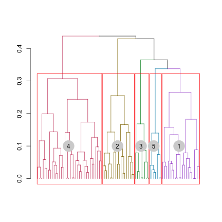

```r
LGs_upgma <- group_upgma(mark_all_f2, expected.groups = 5, inter = F)
plot(LGs_upgma)
```

You can define the expected number of groups in the `expected.groups` argument and check how the markers are split in the plotted dendrogram. Using argument `inter=TRUE` you can change interactively the number of groups defined by the red squares in the graphic.

If you have reference genome information for some of your markers, you can separate the groups using it and the `group_seq` function (further information in `Using the recombinations and the reference genome information`) to add the markers without reference genome information. We can also confirm the separation of linkage groups in the ordering procedure.

Notice the class of object `LGs_f2` and `LGs_upgma`:

```r
class(LGs_f2)
```

```
#> [1] "group"
```

```r
class(LGs_upgma)
```

```
#> [1] "group.upgma"
```

### Ordering markers within linkage groups

After assigning markers to linkage groups, the next step is to order the markers within each group.

First, let us choose the mapping function used to display the genetic map. We can choose between Kosambi or Haldane mapping functions. To use Haldane, type

```r
set_map_fun(type = "haldane")
```

To use Kosambi’s function:

```r
set_map_fun(type = "kosambi")
```

If none is set, kosambi function is applied.

#### Linkage group 1

First, you must `extract` it from the object of class `group`. Let us extract the group 1 using function `make_seq`:

```r
LG1_f2 <- make_seq(LGs_f2, 1)
```

The first argument is an object of class `group` and the second is a number indicating which linkage group will be extracted. In this case, the object `LGs_f2`, generated by function `group`, is of class `group`. In fact, this function can handle different classes of objects.

If you type:

```r
LG1_f2
```

```
#>
#> Number of markers: 36
#> Markers in the sequence:
#> M1 M3 M4 M6 M7 M9 M12 M13 M17 M23 M26 M27 M29 M30 M31 M34 M35 M36 M40 M42 M44
#> M46 M53 M55 M58 M60 M63 SNP1 SNP2 SNP3 SNP5 SNP6 SNP7 SNP8 SNP9 SNP10
#>
#> Parameters not estimated.
```

you will see which markers are comprised in the sequence. But notice that no parameters have been estimated so far (the function says *Parameters not estimated*). This refers to the fact that so far we only attributed markers to linkage groups, but we did not perform any analysis for them as a **group** - only as pairs. (Does it seem complicated? Do not worry, you will understand the details in a moment).

Notice the class of object `LG1_f2`:

```r
class(LG1_f2)
```

```
#> [1] "sequence"
```

To order markers in this group, you can use a two-point based algorithm such as Seriation (Buetow and Chakravarti, 1987), Rapid Chain Delineation (Doerge, 1996), Recombination Counting and Ordering (Van Os et al., 2005) and Unidirectional Growth (Tan and Fu, 2006):

```r
LG1_rcd_f2 <- rcd(LG1_f2, hmm = FALSE)
LG1_rec_f2 <- record(LG1_f2, hmm = FALSE)
LG1_ug_f2 <- ug(LG1_f2, hmm = FALSE)
```

Argument `hmm` defines if the function should run the HMM chain multipoint approach to estimate the genetic distances given the marker order provided by the two-points ordering algorithm. We set here the argument `hmm=FALSE` because we just want to obtain the marker order. We are not yet estimating the genetic distances. We suggest to use `hmm=TRUE` only when you already decided which order is the best because the HMM chain is the most computationally intensive step in the map building (mainly if F2 intercross population). You can use `rf_graph_table` to check the ordering quality (see details below) and make editions in the marker order using `drop_marker`. After, you can use `map` or `map_avoid_unlinked` functions to estimate the genetic distances (check session Map estimation for an arbitrary order).

The algorithms provided different results (results not printed in this vignette). For an evaluation and comparison of these methods, see Mollinari et al. (2009).

In this particular case, seriation will return an expected error:

```r
LG1_ser_f2 <- seriation(LG1_f2, hmm = F) # Will return an error (can not be used in this case)
```

```r
LG1_mds_f2 <- mds_onemap(input.seq = LG1_f2, hmm = F)
```

```
#> Stress: 0.264332027022349
#> Mean Nearest Neighbour Fit: 10.0095819928163
```

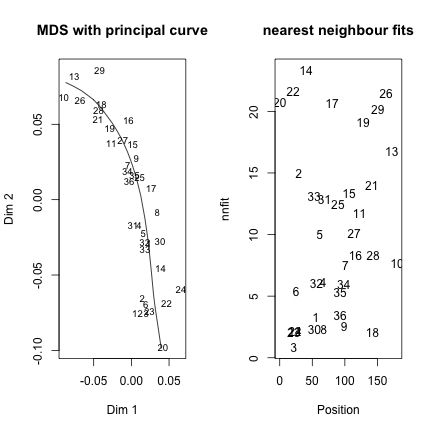

If you only specify the input sequence, mds_onemap will use the default parameters. It will also generate the MDSMap input file in `out.file` file. You can use `out.file` in the MDSMap package to try other parameters too. The default method used is the principal curves, know more about using `?mds_onemap` and reading the MDSMap [vignette](https://CRAN.R-project.org/package=MDSMap). Besides these algorithms use a two-point approach to order the markers, if you set `hmm=TRUE` a multipoint approach is applied to estimate the genetic distances after the order is estimated. Thus, it can happen that some markers are not considered linked when evaluated by multipoint information, and the function will return an error like this:

```
ERROR: The linkage between markers 1 and 2 did not reach the OneMap default criteria. They are probably segregating independently
```

You can automatically remove these markers setting argument `rm_unlinked = TRUE`. The marker will be removed, and the ordering algorithms will be restarted. Warning messages will inform which markers were removed. If you don’t get warning messages, it means that any marker needed to be removed. This is our case in this example, but if you obtain an error or warning running your dataset, you already know what happened.

**NOTE**: (new!) If you are working with f2 intercross mapping population and have many markers (more than 60), we suggest to first use hmm=FALSE to check the ordering and after speed up `mds` using BatchMap parallelization approach. See section `Speed up analysis with parallelization` for more information.

By now, we ordered our group in several ways, but, which one result in the best order? We can check it by plotting the color scale recombination fraction matrix and see if the generated maps obey the colors patterns expected.

# Plotting the recombination fraction matrix

It is possible to plot the recombination fraction matrix and LOD Scores based on a color scale using the function `rf_graph_table`. This matrix can be useful to make some diagnostics about the map.

Ordered markers are presented on both axes. Hotter the colors lower the recombination fraction between markers related to each cell. Good map orders have hot colors in the diagonal and it gradually turns to blue at the superior left and inferior right corners. This pattern means that markers that have low recombination fractions are really positioned closely on the map.

Let’s see the maps we have until now:

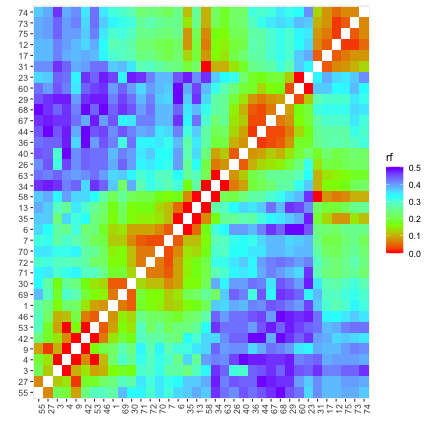

```r
rf_graph_table(LG1_rcd_f2)
```

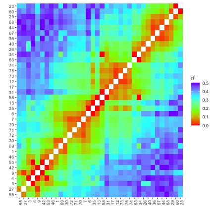

```r
rf_graph_table(LG1_rec_f2)
```

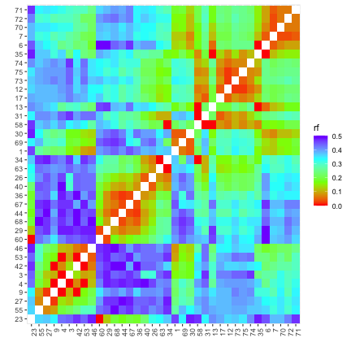

```r
rf_graph_table(LG1_ug_f2)
```

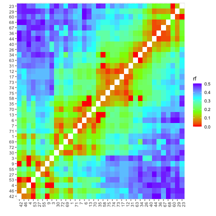

```r
rf_graph_table(LG1_mds_f2)
```

With default arguments, the graphic cells represent the recombination fractions. If you change the argument to `graph.LOD = TRUE`, LOD score values are plotted. The color scale varies from red (small distances and big LODs) to dark blue. You can also change the number of colors from the `rainbow` palette with argument `n.colors`, add/remove graphic main and axis title (`main` and `lab.xy`), and shows marker numbers, instead of names in the axis (`mrk.axis`).

We can see that any of the algorithms gave an optimal ordering, there are many red cells out of the diagonal, the color pattern is broke in all graphics, but we need to do an effort to find which one of the algorithms gave the best result. Then, we continue the analysis by doing hand manipulations.

Here, `mds` and `record` approaches are the ones that gave results more close to the expected pattern. We can also see that probably there is more than one group, because of the big gaps. Let’s see the map generated by the `mds` algorithm with more details using the interactive mode of the `rf_graph_table` function:

```r
rf_graph_table(LG1_mds_f2, inter = TRUE, html.file = "test.html")
```

An interactive version of the graphic will pop up (not shown here) in your internet browser end generated an HTML file in your work directory. Hover the mouse cursor over the cell corresponding to two markers, you can see some useful information about them.

Let’s separate the other groups and order again using the same method:

```r
LG2_f2 <- make_seq(LGs_f2, 2)
LG2_mds_f2 <- mds_onemap(LG2_f2,hmm = FALSE)
```

```
#> Stress: 0.119539392828496
#> Mean Nearest Neighbour Fit: 8.68976273539295
```

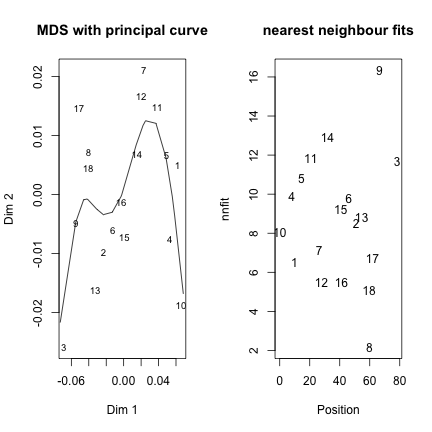

```r
LG3_f2 <- make_seq(LGs_f2, 3)
LG3_mds_f2 <- mds_onemap(LG3_f2,hmm = FALSE)
```

```
#> Stress: 0.220844096570945
#> Mean Nearest Neighbour Fit: 9.5840299119882
```

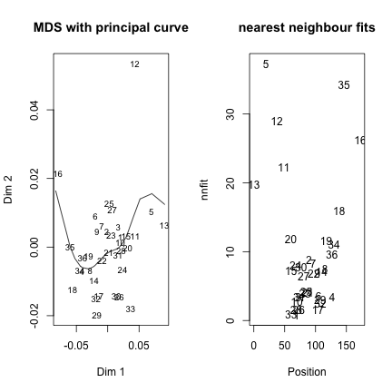

## Linkage group 1

When possible (*i.e.*, when groups have a small number of markers, in general up to 10 or 11), one should select the best order by comparing the multipoint likelihood of all possible orders between markers (exhaustive search). This procedure is implemented in the function `compare`. Although feasible for up to 10 or 11 markers, with 7 or more markers it will take a couple of hours until you see the results (depending of course on the computational resources available).

All our groups have more than 7 markers, so using the function `compare` is infeasible. Thus we will apply a heuristic that shows reliable results. First, we will choose a moderate number of markers, say 6, to create a framework using the function `compare`, and then we will position the remaining markers into this framework using the function `try_seq`. The way we choose these initial markers in inbred-based populations is somewhat different from what we did for outcrossing populations, where there is a mixture of segregation patterns (see the vignette for details).

In our scenario, we recommend two methods:

1. Randomly choose a number of markers and calculate the multipoint likelihood of all possible orders (using the function `compare`). If the LOD Score of the second-best order is greater than a given threshold, say, 3, then take the best order to proceed with the next step. If not, repeat the procedure.
2. Use some two-point based algorithm to construct a map; then, take equally spaced markers from this map. Then, create a framework of ordered markers using the function `compare`. Next, try to map the remaining markers, one at a time, beginning with co-dominant ones (most informative ones), then add the dominant ones.

You can do this procedure manually, in a similar way as done for outcrossing species (see the vignette for details). However, this procedure is automated in function `order_seq`, which we will use here (it will take some time to run):

```r
LG1_f2_ord <- order_seq(input.seq = LG1_mds_f2, n.init = 5,
                        subset.search = "twopt",
                        twopt.alg = "rcd", THRES = 3)
```

The first argument is an object of class `sequence` (LG1_mds_f2). `n.init = 5` means that five markers will be used in the `compare` step. The argument `subset.search = "twopt"` indicates that these five markers should be chosen by using a two-point method, which will be Rapid Chain Delineation, as indicated by the argument `twopt.alg = "rcd"`. `THRES = 3` indicates that the `try_seq` step will only add markers to the sequence which can be mapped with LOD Score greater than 3.

Check the order obtained by this procedure:

```r
LG1_f2_ord # Results not shown in this vignette
```

To get the `safe` order, use:

```r
LG1_f2_safe <- make_seq(LG1_f2_ord, "safe")
```

and to get the order with all markers (*i.e.*, including the ones not mapped to a single position), use:

```r
(LG1_f2_all <- make_seq(LG1_f2_ord, "force"))
```

Although some old publications presented maps with only `safe` orders, we see no reason not to use the option `force` and recommend it for users. In the next, steps we can make modifications to the map based on more information.

The `order_seq` function can perform two rounds of the `try_seq` step, first using `THRES` and then `THRES - 1` as the threshold. This generally results in safe orders with more markers mapped but takes longer to run. To do this, type (it will take some time to run):

```r
LG1_f2_ord <- order_seq(input.seq = LG1_mds_f2, n.init = 5,
                        subset.search = "twopt",
                        twopt.alg = "rcd", THRES = 3,
                        touchdown = TRUE)
```

[output not shown]

```r
(LG1_f2_final <- make_seq(LG1_f2_ord, "force"))
```

```
#>
#> Printing map:
#>
#> Markers           Position           Parent 1       Parent 2
#>
#> 55 M55                0.00           a |  | b       a |  | b
#>  9 M9                 7.42           o |  | o       a |  | o
#> 27 M27                8.20           a |  | b       a |  | b
#>  3 M3                19.85           o |  | o       a |  | o
#>  4 M4                22.96           o |  | a       o |  | o
#> 42 M42               29.13           o |  | a       o |  | o
#> 53 M53               30.37           o |  | o       a |  | o
#> 46 M46               34.76           a |  | b       a |  | b
#>  1 M1                43.31           a |  | b       a |  | b
#> 69 SNP3              48.45           a |  | b       a |  | b
```

[output cut: 28 more lines]

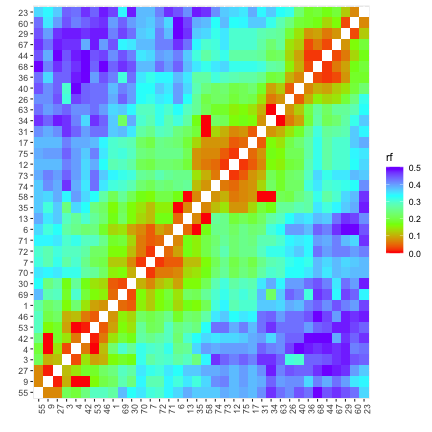

```r
rf_graph_table(LG1_f2_final)
```

Finally, to check for alternative orders, use the `ripple_seq` function:

```r
ripple_seq(LG1_f2_final, ws = 5, LOD = 3)
```

The second argument, `ws = 5`, means that subsets (windows) of five markers will be permuted sequentially (5! orders for each window), to search for other plausible orders. The `LOD` argument means that only orders with LOD Score smaller than 3 will be printed.

The output shows sequences of five numbers, because `ws = 5`. They can be followed by an `OK`, if there are no alternative orders with LOD Scores smaller than `LOD = 3` in absolute value, or by a list of alternative orders.

## Linkage group 2

Here we will use the multipoint approach to re-order the LG2. The approach is the automatic usage of the `try` algorithm:

```r
LG2_f2_ord <- order_seq(input.seq = LG2_mds_f2, n.init = 5,
                        subset.search = "twopt",
                        twopt.alg = "rcd", THRES = 3,
                        touchdown = TRUE, rm_unlinked = TRUE)
```

Get the order with all markers:

```r
(LG2_f2_final <- make_seq(LG2_f2_ord, "force"))
```

```
#>
#> Printing map:
#>
#> Markers           Position           Parent 1       Parent 2
#>
#> 41 M41                0.00           a |  | b       a |  | b
#> 10 M10                8.48           a |  | b       a |  | b
#>  2 M2                15.92           o |  | a       o |  | o
#> 11 M11               18.70           o |  | a       o |  | o
#> 43 M43               22.22           a |  | b       a |  | b
#> 32 M32               26.58           o |  | o       a |  | o
#> 45 M45               31.50           o |  | a       o |  | o
#> 54 M54               34.03           a |  | b       a |  | b
#> 66 M66               40.90           a |  | b       a |  | b
#> 61 M61               42.58           a |  | b       a |  | b
#> 25 M25               48.19           a |  | b       a |  | b
#>  5 M5                51.79           o |  | a       o |  | o
#> 51 M51               56.09           o |  | a       o |  | o
#> 90 SNP26             64.25           a |  | b       a |  | b
#> 33 M33               65.61           a |  | b       a |  | b
#> 89 SNP24             70.35           a |  | b       a |  | b
#> 37 M37               78.54           a |  | b       a |  | b
#>  8 M8                84.79           o |  | a       o |  | o
#>
#> 18 markers            log-likelihood: -1259.53
```

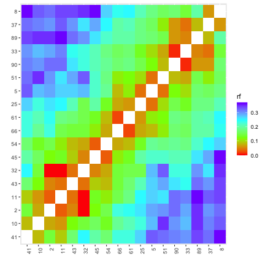

```r
rf_graph_table(LG2_f2_final)
```

Our heatmap is already very good with an automatic approach, but I may want to see what happens if I remove a marker and try to reposition it. To remove a marker use function `drop_marker`:

```r
LG2_edit <- drop_marker(LG2_f2_final, 41) # removing marker 41
```

After, you need to re-estimate the parameters using the same previous order. For that, use the `map` function:

```r
LG2_edit_map <- map(LG2_edit)
```

**Warning**: If you find an error message like:

```
Error in as_mapper(.f, ...) : argument ".f" is missing, with no default
```

It’s because the `map` function has a very common name and you can have in your environment other functions with the same name. In the case of the presented error, R is using the `map` function from `purrr` package instead of `OneMap`, to solve this, simply specify that you want the `OneMap` function with `::` command from `stringr` package:

```r
library(stringr)
LG2_edit_map <- onemap::map(LG2_edit)
```

**NOTE**: (new!) If you are working with f2 intercross mapping population and have many markers (more than 60), we suggest to speed up `map` using BatchMap parallelization approach. See section `Speed up analysis with parallelization` for more information.

See what happened:

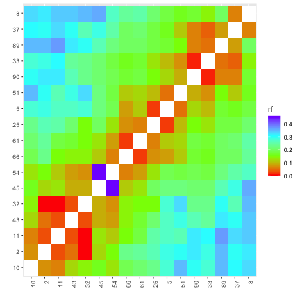

```r
rf_graph_table(LG2_edit_map)
```

And try to reposition the marker:

```r
(LG2_temp <- try_seq(input.seq = LG2_edit_map, mrk = 41))
```

[output not shown]

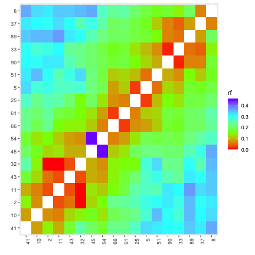

```r
LG2_f2_final <- make_seq(LG2_temp, 1)

rf_graph_table(LG2_f2_final)
```

Check the final map (results not shown):

```r
ripple_seq(LG2_f2_final, ws = 5)
```

Print it:

```r
LG2_f2_final
```

```
#>
#> Printing map:
#>
#> Markers           Position           Parent 1       Parent 2
#>
#> 41 M41                0.00           a |  | b       a |  | b
#> 10 M10                8.42           a |  | b       a |  | b
#>  2 M2                15.85           o |  | a       o |  | o
#> 11 M11               18.55           o |  | a       o |  | o
#> 43 M43               21.84           a |  | b       a |  | b
#> 32 M32               25.02           o |  | o       a |  | o
#> 45 M45               33.79           a |  | o       o |  | o
#> 54 M54              111.76           b |  | a       a |  | b
#> 66 M66              118.27           b |  | a       a |  | b
#> 61 M61              119.89           b |  | a       a |  | b
#> 25 M25              125.62           b |  | a       a |  | b
#>  5 M5               127.68           a |  | o       o |  | o
#> 51 M51              132.60           a |  | o       o |  | o
#> 90 SNP26            141.93           b |  | a       a |  | b
#> 33 M33              143.28           b |  | a       a |  | b
#> 89 SNP24            148.00           b |  | a       a |  | b
#> 37 M37              156.18           b |  | a       a |  | b
#>  8 M8               162.37           a |  | o       o |  | o
#>
#> 18 markers            log-likelihood: -1410.763
```

This is the final version of the map for this linkage group.

#### Linkage group 3

Automatic usage of try algorithm.

```r
LG3_f2_ord <- order_seq(input.seq = LG3_mds_f2, n.init = 5,
                        subset.search = "twopt",
                        twopt.alg = "rcd", THRES = 3,
                        touchdown = TRUE)
```

A careful examination of the graphics can be a good source of information about how markers were placed.

Now, get the order with all markers:

```r
(LG3_f2_final <- make_seq(LG3_f2_ord, "force"))
```

```
#>
#> Printing map:
#>
#> Markers           Position           Parent 1       Parent 2
#>
#> 47 M47                0.00           a |  | b       a |  | b
#> 19 M19                7.71           o |  | a       o |  | o
#> 39 M39                8.94           o |  | o       a |  | o
#> 38 M38               15.62           a |  | b       a |  | b
#> 49 M49               23.51           o |  | o       a |  | o
#> 59 M59               23.77           o |  | a       o |  | o
#> 80 SNP15             34.43           a |  | b       a |  | b
#> 76 SNP11             38.32           a |  | b       a |  | b
#> 28 M28               40.17           a |  | b       a |  | b
#> 78 SNP13             43.74           a |  | b       a |  | b
```

[output cut: 28 more lines]

Check heatmap:

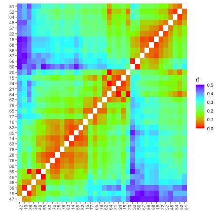

```r
rf_graph_table(LG3_f2_final)
```

Markers `24` and `64` seem to broke the color pattern. We will remove them and use try_seq to find better locations:

```r
LG3_edit <- drop_marker(LG3_f2_final, c(24, 64))
LG3_edit_map <- order_seq(LG3_edit) # We remove several markers maybe it's better to order again
```

[output not shown]

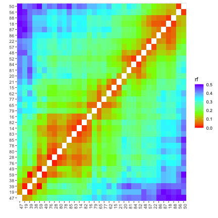

```r
LG3_edit_map <- make_seq(LG3_edit_map, "force")

rf_graph_table(LG3_edit_map)
```

Adding one by one we can see how each one changes the map log-likelihood, map size, and the color pattern in the heatmap and judge if we will remove them.

```r
LG3_edit <- try_seq(LG3_edit_map, 24)
LG3_edit_temp <- make_seq(LG3_edit, 22)
LG3_edit_map <- LG3_edit_temp # include
LG3_edit <- try_seq(LG3_edit_map, 64)
LG3_edit_temp <- make_seq(LG3_edit, 24) # Not included

LG3_f2_final <- LG3_edit_map
```

Check the final map (not shown):

```r
ripple_seq(LG3_f2_final, ws = 5)
```

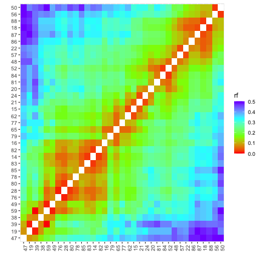

```r
rf_graph_table(LG3_f2_final)
```

## Using the recombinations and the reference genome information

In our example, we have reference genome chromosome and position information for some of the markers, here we will exemplify one method of using this information to help build the genetic map.

With the `CHROM` information in the input file, you can identify markers belonging to some chromosome using the function `make_seq` with the `rf_2pts` object. For example, assign the string `"1"` for the second argument to get chromosome 1 makers. The output sequence will be automatically ordered by `POS` information.

```r
CHR1 <- make_seq(twopts_f2, "1")
CHR1
```

```
#>
#> Number of markers: 9
#> Markers in the sequence:
#> SNP1 SNP2 SNP3 SNP5 SNP6 SNP7 SNP8 SNP9 SNP10
#>
#> Parameters not estimated.
```

```r
CHR2 <- make_seq(twopts_f2, "2")
CHR3 <- make_seq(twopts_f2, "3")
```

### Adding markers with no reference genome information

According to `CHROM` information we have three defined linkage groups, now we can try to group the markers without chromosome information to them using recombination information. For this, we can use the function `group_seq`:

```r
CHR_mks <- group_seq(input.2pts = twopts_f2, seqs = "CHROM", unlink.mks = mark_all_f2,
                     repeated = FALSE)
```

```
#>    Selecting markers:
#>    group    1
#>     ...................................
#>    group    2
#>     ...............
#>    group    3
#>     ......................
#>    Selecting markers:
#>    group    1
#>     ...................................
#>    group    2
#>     ..........................
#>    group    3
#>     ...............
#>    Selecting markers:
#>    group    1
#>     .................
#>    group    2
#>     ..........................
#>    group    3
#>     ......................
```

The function works as the function `group` but considering pre-existing sequences. Setting `seqs` argument with the string `"CHROM"`, it will consider the pre-existing sequences according to `CHROM` information. You can also indicate other pre-existing sequences if it makes sense for your study. For that, you should inform a list with objects of class `sequences`, as the example:

```r
CHR_mks <- group_seq(input.2pts = twopts_f2, seqs = list(CHR1=CHR1, CHR2=CHR2, CHR3=CHR3),
                     unlink.mks = mark_all_f2, repeated = FALSE)
```

In this case, the command had the same effect as the previous, because we indicate chromosome sequences, but others sequences can be used.

In some cases, the same marker can group into more than one sequence, those markers will be considered `repeated`. We can choose if we want to remove or not (`FALSE/TRUE`) them of the output sequences, with the argument `rm.repeated`. Anyway, their numbers will be informed at the list `repeated` in the output object.

In the example case, there are no repeated markers. However, if they exist, it could indicate that their groups actually constitute the same group. Also, genotyping errors can generate repeated markers. Anyway, they deserve better investigations.

We can access detailed information about the results just by printing:

```r
CHR_mks
```

```
#>   This is an object of class 'group_seq'
#>   Criteria used to assign markers to groups:
#>     LOD = 3 , Maximum recombination fraction = 0.5
#>
#>   No. markers in input sequences:
#>                        CHR1 :   9 markers
#>                        CHR2 :   13 markers
#>                        CHR3 :   2 markers
#>
#>   No. unlinked input markers:   66 markers
#>
#>   No. markers in output sequences:
#>                        CHR1 :   36 markers
#>                        CHR2 :   36 markers
#>                        CHR3 :   18 markers
#>   No. unlinked:                 0 markers
#>   No. repeated:                 0 markers
#>
#>   Printing output sequences:
#>   Group CHR1 : 36 markers
#>     SNP1 SNP2 SNP3 SNP5 SNP6 SNP7 SNP8 SNP9 SNP10 M1 M3 M4 M6 M7 M9 M12 M13 M17 M23 M26 M27 M29 M30 M31 M34 M35 M36 M40 M42 M44 M46 M53 M55 M58 M60 M63
#>
#>   Group CHR2 : 36 markers
#>     SNP11 SNP12 SNP13 SNP14 SNP15 SNP16 SNP17 SNP18 SNP19 SNP20 SNP21 SNP22 SNP23 M14 M15 M16 M18 M19 M20 M21 M22 M24 M28 M38 M39 M47 M48 M49 M50 M52 M56 M57 M59 M62 M64 M65
#>
#>   Group CHR3 : 18 markers
#>     SNP24 SNP26 M2 M5 M8 M10 M11 M25 M32 M33 M37 M41 M43 M45 M51 M54 M61 M66
#>
#>   Unlinked markers: 0 markers
#>
#>
#>   Repeated markers: 0  markers
#>
```

Also, we can access the numbers of repeated markers with:

```r
CHR_mks$repeated
```

```
#> [1] NA
```

In the same way, we can access the output sequences:

```r
CHR_mks$sequences$CHR1
```

```
#>
#> Number of markers: 36
#> Markers in the sequence:
#> SNP1 SNP2 SNP3 SNP5 SNP6 SNP7 SNP8 SNP9 SNP10 M1 M3 M4 M6 M7 M9 M12 M13 M17 M23
#> M26 M27 M29 M30 M31 M34 M35 M36 M40 M42 M44 M46 M53 M55 M58 M60 M63
#>
#> Parameters not estimated.
```

```r
# or
CHR_mks$sequences[[1]]
```

```
#>
#> Number of markers: 36
#> Markers in the sequence:
#> SNP1 SNP2 SNP3 SNP5 SNP6 SNP7 SNP8 SNP9 SNP10 M1 M3 M4 M6 M7 M9 M12 M13 M17 M23
#> M26 M27 M29 M30 M31 M34 M35 M36 M40 M42 M44 M46 M53 M55 M58 M60 M63
#>
#> Parameters not estimated.
```

For this function, optional arguments are `LOD` and `max.rf`, which define thresholds to be used when assigning markers to linkage groups. If none is provided (default), criteria previously defined for the object `rf_2pts` are used.

# Map estimation for an arbitrary order

If you have some information about the order of the markers, for example, from a reference genome or previously published paper, you can define a sequence of those markers in a specific order (using the function `make_seq`) and then use the function `map` to estimate the final genetic map (based on multi-point analysis). For example, let us assume that we know that the following markers are ordered in this sequence: `M47`, `M38`, `M59`, `M16`, `M62`, `M21`, `M20`, `M48` and `M22`. In this case, select them from the two-point analysis, and use function `map`:

```r
LG3seq_f2 <- make_seq(twopts_f2, c(47, 38, 59, 16, 62, 21, 20, 48, 22))
```

```r
LG3seq_f2_map <- map(LG3seq_f2)
```

**Warning**: If you find an error message like:

```
Error in as_mapper(.f, ...) : argument ".f" is missing, with no default
```

It’s because the `map` function has a very common name and you can have in your environment another function with the same name. In the case of the presented error, R is using the `map` function from `purrr` package instead of `OneMap`, to solve this, simply specify that you want the `OneMap` function with `::` command from `stringr` package:

```r
library(stringr)
(LG3seq_f2_map <- onemap::map(LG3seq_f2))
```

```
#>
#> Printing map:
#>
#> Markers           Position           Parent 1       Parent 2
#>
#> 47 M47                0.00           a |  | b       a |  | b
#> 38 M38               14.69           a |  | b       a |  | b
#> 59 M59               24.45           o |  | a       o |  | o
#> 16 M16               38.96           a |  | b       a |  | b
#> 62 M62               49.22           a |  | b       a |  | b
#> 21 M21               56.19           a |  | b       a |  | b
#> 20 M20               65.10           o |  | o       a |  | o
#> 48 M48               73.14           a |  | b       a |  | b
#> 22 M22               81.80           a |  | b       a |  | b
#>
#> 9 markers            log-likelihood: -1004.624
```

**NOTE**: (new!) If your map population is F2 intercross and your sequence has many markers (more than 60), we suggest to speed up `map` using BatchMap parallelization approach. See section `Speed up analysis with parallelization` for more information.

To see the correspondence between marker names and numbers, use function `marker_type`:

```r
marker_type(LG3seq_f2_map)
```

```
#>   Marker Marker.name  Type
#> 1     47         M47 A.H.B
#> 2     38         M38 A.H.B
#> 3     59         M59   C.A
#> 4     16         M16 A.H.B
#> 5     62         M62 A.H.B
#> 6     21         M21 A.H.B
#> 7     20         M20   D.B
#> 8     48         M48 A.H.B
#> 9     22         M22 A.H.B
```

If one needs to add or drop markers from a predefined sequence, functions `add_marker` and `drop_marker` can be used. For example, to add markers `M18`, `M56` and `M50` at the end of `LG3seq_f2_map`:

```r
(LG3seq_f2_map <- add_marker(LG3seq_f2_map, c(18, 56, 50)))
```

```
#>
#> Number of markers: 12
#> Markers in the sequence:
#> M47 M38 M59 M16 M62 M21 M20 M48 M22 M18 M56 M50
#>
#> Parameters not estimated.
```

Removing markers `M59` and `21` from `LG3seq_f2_map`:

```r
(LG3seq_f2_map <- drop_marker(LG3seq_f2_map, c(59, 21)))
```

```
#>
#> Number of markers: 10
#> Markers in the sequence:
#> M47 M38 M16 M62 M20 M48 M22 M18 M56 M50
#>
#> Parameters not estimated.
```

# Drawing the genetic map

Once all linkage groups were obtained using both strategies, we can draw a map for each strategy using the function `draw_map`. Since version 2.1.1007, `OneMap` has a new version of `draw_map`, called `draw_map2`. The new function draws elegant linkage groups and presents new arguments to personalize your draw.

If you prefer the old function, we also keep it. Follow examples of how to use both of them.

## `Draw_map`

We can draw a genetic map for all linkage groups using the function `draw_map`. First, we have to create a list of ordered linkage groups:

```r
maps_list <- list(LG1_f2_final, LG2_f2_final, LG3_f2_final)
```

Then use function `draw_map` for this list:

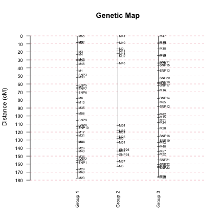

```r
draw_map(maps_list, names = TRUE, grid = TRUE, cex.mrk = 0.7)
```

We also can draw a map for a specific linkage group:

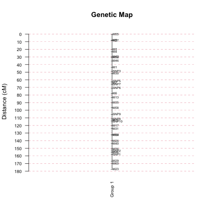

```r
draw_map(LG1_f2_final, names = TRUE, grid = TRUE, cex.mrk = 0.7)
```

Function `draw_map` draws a very simple graphic representation of the genetic map. More recently, we developed a new version called `draw_map2` that draws a more sophisticated figure. Furthermore, once the distances and the linkage phases are estimated, other map figures can be drawn by the user with any appropriate software.

## `Draw_map2`

The same figures did with `draw_map` can be done with the `draw_map2` function. But it has different capacities and arguments. Here are some examples, but you can find more options on the help page `?write_map2`.

```r
draw_map2(LG1_f2_final, LG2_f2_final, main = "Only linkage information",
          group.names = c("LG1", "LG2", "LG3"), output = "map.eps")
```

*NOTE*: Check the [GitHub vignette version](https://statgen-esalq.github.io/tutorials/onemap/Inbred_Based_Populations.html) to visualize the graphic.

You can include all `sequence` objects referring to the groups as the first arguments. The `main` argument defines the main title of the draw and `group.names` define the names of each group. If no `output` file and file extension is defined, the draw will be generated at your working directory as `map.eps`. The eps extension is only the default option but there are others that can be used. You can have access to a list of them on the help page.

We also can draw a map for a specific linkage group:

```r
draw_map2(LG1_f2_final, col.group = "#58A4B0", col.mark = "#335C81", output = "map_LG1.pdf")
```

*NOTE*: Check the [GitHub vignette version](https://statgen-esalq.github.io/tutorials/onemap/Inbred_Based_Populations.html) to visualize the graphic.

You can also change the default colors using the `col.group` and `col.mark` arguments.

With argument `tag` you can highlight some markers at the figure according to your specific purpose.

# Speed up analysis with parallelization (new!)

**Warning**: Only available for outcrossing and f2 intercross populations.

As already mentioned, `OneMap` uses HMM multipoint approach to estimate genetic distances, a very robust method, but it can take time to run if you have many markers. In 2017, Schiffthaler et. al release an `OneMap` fork with modifications in CRAN and in GitHub with the possibility of parallelizing the HMM chain dividing markers in batches and use different cores for each phase. Their approach speeds up our HMM and keeps the genetic distances estimation quality. It allows dividing the job into a maximum of four cores according to the four possible phases for outcrossing and f2 mapping populations. We add this parallelized approach to the functions: `map`, `mds_onemap`, `seriation`, `rcd`, `record` and `ug`. For better efficiency it is important that batches are composed of 50 markers or more, therefore, this approach is only recommended for linkage groups with many markers.

The parallelization is here available for all types of operational systems, however, we suggest setting argument `parallelization.type` to `FORK` if you are not using Windows system. It will improve the procedure speed.

Here we will show an example of how to use the BatchMap approach in some functions that requires HMM. For this, we simulated a dataset with a group with 300 markers (we don’t want this vignette to take too much time to run, but usually maps with markers from high-throughput technologies result in larger groups). Before start, you can see the time spent for each approach (See also Session Info) in this example:

|  | Without parallelization (h) | With parallelization (h) |
| --- | --- | --- |
| rcd | 0.6801889 | 0.1260436 |
| record_map | 1.8935892 | 0.3330297 |
| ug_map | 1.1002725 | 0.2256356 |
| mds_onemap | 2.1478900 | 0.4443492 |
| map | 2.1042114 | 0.6156722 |

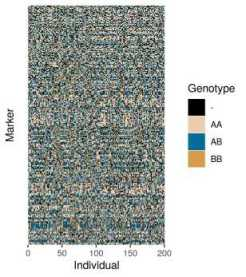

```r
simParallel <- read_onemap(system.file("extdata/simParall_f2.raw", package = "onemap")) # dataset available only in onemap github version
plot(simParallel)
```

```r
# Calculates two-points recombination fractions
twopts <- rf_2pts(simParallel)

seq_all <- make_seq(twopts, "all")

# There are no redundant markers
find_bins(simParallel)

# There are no distorted markers
print(test_segregation(simParallel)) # Not shown
```

To prepare the data with defined bach size we use function `pick_batch_sizes`. It selects a batch size that splits the data into even groups. Argument `size` defines the batch size next to which an optimum size will be searched. `overlap` defines the number of markers that overlap between the present batch and next. This is used because pre-defined phases at these overlap markers in the present batch are used to start the HMM in the next batch. The `around` argument defines how much the function can vary around the defined number in `size` to search for the optimum batch size.

Some aspects should be considered to define these arguments because if the batch size were set too high, there would be less gain in execution time. If the overlap size would be too small, phases would be incorrectly estimated and large gaps would appear in the map, inflating its size. In practice, these values will depend on many factors such as population size, marker quality, and species. BatchMap authors recommended trying several configurations on a subset of data and select the best performing one.

```r
batch_size <- pick_batch_sizes(input.seq = seq_all,
                               size = 80,
                               overlap = 30,
                               around = 10)

batch_size
```

## Speed up two-points ordering approaches

To use the parallelized approach you just need to include the arguments when using the functions:

```r
# Without parallelization
rcd_map <- rcd(input.seq = seq_all)

# With parallelization
rcd_map_par <- rcd(input.seq = seq_all,
                   phase_cores = 4,
                   size = batch_size,
                   overlap = 30)
```

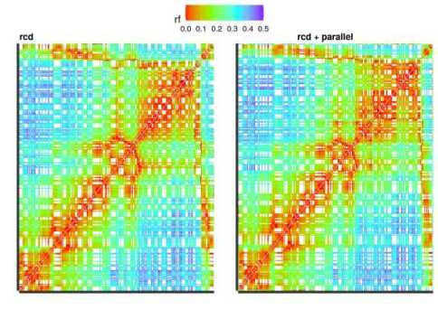

```r
# Without parallelization
record_map <- record(input.seq = seq_all)

# With parallelization
record_map_par <- record(input.seq = seq_all,
                         phase_cores = 4,
                         size = batch_size,
                         overlap = 30)
```

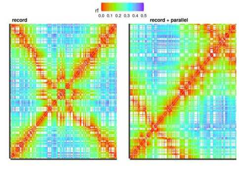

```r
# Without parallelization
ug_map <- ug(input.seq = seq_all)

# With parallelization
ug_map_par <- ug(input.seq = seq_all,
                 phase_cores = 4,
                 size = batch_size,
                 overlap = 30)
```

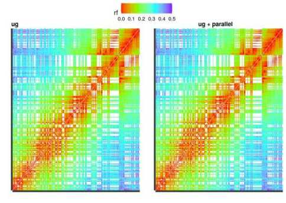

## Speed up mds_onemap

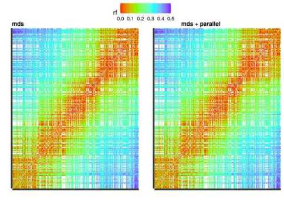

```r
# Without parallelization ok
map_mds <- mds_onemap(input.seq = seq_all)

# With parallelization
map_mds_par <- mds_onemap(input.seq = seq_all,
                          phase_cores = 4,
                          size = batch_size,
                          overlap = 30)
```

## Speed up map estimation for an arbitrary order (map function)

Because we simulate this dataset we know the correct order. We can use `map_overlapping_batches` to estimate genetic distance in this case. This is equivalent to `map`, but with the parallelized process.

Similarly with `map`, using argument `rm_unlinked = TRUE` the function will return a vector with marker numbers without the problematic marker. To repeat the analysis removing automatically all problematic markers use `map_avoid_unlinked`:

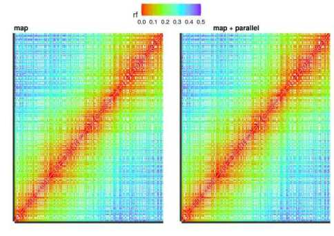

```r
# Without parallelization
batch_map <- map_avoid_unlinked(input.seq = seq_all)

# With parallelization
batch_map_par <- map_avoid_unlinked(input.seq = seq_all,
                                    size = batch_size,
                                    phase_cores = 4,
                                    overlap = 30)
```

As you can see in the above maps, heuristic ordering algorithms do not return an optimal order result, mainly if you don’t have many individuals in your population. Because of the erroneous order, generated map sizes are not close to the simulated size (100 cM) and their heatmaps don’t present the expected color pattern. Two of them get close to the color pattern, they are the ug and the MDS method. They present good global ordering but not local. If you have a reference genome, you can use its position information to rearrange local ordering.

# Export estimated progeny haplotypes (new!)

Function `progeny_haplotypes` generates a data.frame with progeny phased haplotypes estimated by `OneMap` HMM. For progeny, the HMM results in probabilities for each possible genotype, then the generated data.frame contains all possible genotypes. If `most_likely = TRUE` the most likely genotype receives 1 and the rest 0 (if there are two most likely both receive 0.5), if `most_likely = FALSE` genotypes probabilities will be according to the HMM results. You can choose which individual to be evaluated in `ind`. The data.frame is composed of the information: individual (ind) and group (grp) ID, position in centimorgan (pos), progeny homologs (homologs), and from each parent the allele came (parents).

```r
(progeny_haplot <- progeny_haplotypes(LG2_f2_final, most_likely = TRUE, ind = 2, group_names = "LG2_final"))
```

```
#>     ind marker       grp        pos prob progeny.homologs parents allele
#> 1  IND2    M41 LG2_final   0.000000    0               H1      P1  H1_P1
#> 2  IND2    M10 LG2_final   8.424187    0               H1      P1  H1_P1
#> 3  IND2     M2 LG2_final  15.850115    0               H1      P1  H1_P1
#> 4  IND2    M11 LG2_final  18.551137    0               H1      P1  H1_P1
#> 5  IND2    M43 LG2_final  21.837171    0               H1      P1  H1_P1
#> 6  IND2    M32 LG2_final  25.016215    0               H1      P1  H1_P1
#> 7  IND2    M45 LG2_final  33.788013    0               H1      P1  H1_P1
#> 8  IND2    M54 LG2_final 111.760402    1               H1      P1  H1_P1
#> 9  IND2    M66 LG2_final 118.274227    1               H1      P1  H1_P1
#> 10 IND2    M61 LG2_final 119.889976    1               H1      P1  H1_P1
#> 11 IND2    M25 LG2_final 125.621045    1               H1      P1  H1_P1
#> 12 IND2     M5 LG2_final 127.683342    1               H1      P1  H1_P1
#> 13 IND2    M51 LG2_final 132.604058    1               H1      P1  H1_P1
#> 14 IND2  SNP26 LG2_final 141.928325    0               H1      P1  H1_P1
```

[output cut: 58 more lines]

You can also have a view of progeny estimated haplotypes using `plot`. It shows which markers came from each parent’s homologs. `position` argument defines if haplotypes will be plotted by homologs (`stack`) or alleles (`split`). `split` option is a good way to better view the likelihoods of each allele.

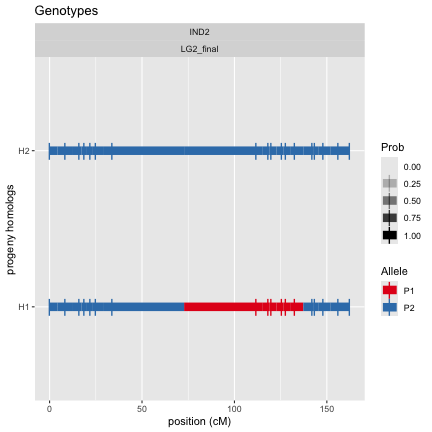

```r
plot(progeny_haplot, position = "stack")
```

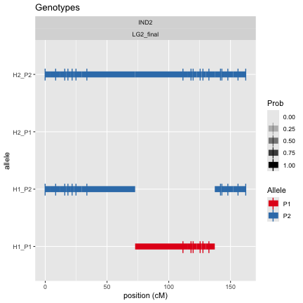

```r
plot(progeny_haplot, position = "split")
```

# A Simpler and More Efficient Way to Save OneMap R Objects for Future Use

OneMap is designed with a nested object structure, ensuring that every `sequence` object contains all the necessary information to reproduce your analysis. While this structure enhances recoverability and organization, it can lead to significantly large objects when saving your data. To address this, we have developed functions to streamline and optimize the saving process.

```r
my_sequences <- list(LG1_f2_final, LG2_f2_final, LG2_f2_final)

save_onemap_sequences(my_sequences, filename = "f2_final_sequences.RData")

my_sequences <- load_onemap_sequences("f2_final_sequences.RData")

# access the sequences
my_sequences[[1]]

# access the onemap object
onemap.obj <- my_sequences[[1]]$data.name

# access the twopoints object
onemap.obj <- my_sequences[[1]]$twopt
```

# Final remarks

At this point, it should be clear that any potential `OneMap` user must have some knowledge about genetic mapping and also the R language, because the analysis is not done with *only one mouse click*. In the future, perhaps a graphical interface will be made available to make this software is a lot easier to use.

We do hope that `OneMap` is useful to researchers interested in genetic mapping in outcrossing or inbred-based populations. Any suggestions and critics are welcome.

[session information not shown]

# References

Adler, J. *R in a Nutshell* A Desktop Quick Reference, 2009.

Broman, K. W., Wu, H., Churchill, G., Sen, S., Yandell, B. *qtl: Tools for analyzing QTL experiments* R package version 1.09-43, 2008.

Buetow, K. H., Chakravarti, A. Multipoint gene mapping using seriation. I. General methods. *American Journal of Human Genetics* 41, 180-188, 1987.

Doerge, R.W. Constructing genetic maps by rapid chain delineation. *Journal of Agricultural Genomics* 2, 1996.

Garcia, A.A.F., Kido, E.A., Meza, A.N., Souza, H.M.B., Pinto, L.R., Pastina, M.M., Leite, C.S., Silva, J.A.G., Ulian, E.C., Figueira, A. and Souza, A.P. Development of an integrated genetic map of a sugarcane *Saccharum spp.* commercial cross, based on a maximum-likelihood approach for estimation of linkage and linkage phases. *Theoretical and Applied Genetics* 112, 298-314, 2006.

Haldane, J. B. S. The combination of linkage values and the calculation of distance between the loci of linked factors. *Journal of Genetics* 8, 299-309, 1919.

Jiang, C. and Zeng, Z.-B. Mapping quantitative trait loci with dominant and missing markers in various crosses from two inbred lines. *Genetica* 101, 47-58, 1997.

Kosambi, D. D. The estimation of map distance from recombination values. *Annuaire of Eugenetics* 12, 172-175, 1944.

Lander, E. S. and Green, P. Construction of multilocus genetic linkage maps in humans. *Proc. Natl. Acad. Sci. USA* 84, 2363-2367, 1987.

Lander, E.S., Green, P., Abrahanson, J., Barlow, A., Daly, M.J., Lincoln, S.E. and Newburg, L. MAPMAKER, An interactive computing package for constructing primary genetic linkage maps of experimental and natural populations. *Genomics* 1, 174-181, 1987.

Lincoln, S. E., Daly, M. J. and Lander, E. S. Constructing genetic linkage maps with MAPMAKER/EXP Version 3.0: a tutorial and reference manual. *A Whitehead Institute for Biomedical Research Technical Report* 1993.

Matloff, N. *The Art of R Programming*. 2011. 1st ed. San Francisco, CA: No Starch Press, Inc., 404 pages.

Margarido, G. R. A., Souza, A.P. and Garcia, A. A. F. OneMap: software for genetic mapping in outcrossing species. *Hereditas* 144, 78-79, 2007.

Mollinari, M., Margarido, G. R. A., Vencovsky, R. and Garcia, A. A. F. Evaluation of algorithms used to order markers on genetics maps. *Heredity* 103, 494-502, 2009.

Oliveira, K.M., Pinto, L.R., Marconi, T.G., Margarido, G.R.A., Pastina, M.M., Teixeira, L.H.M., Figueira, A.M., Ulian, E.C., Garcia, A.A.F., Souza, A.P. Functional genetic linkage map on EST-markers for a sugarcane (*Saccharum spp.*) commercial cross. *Molecular Breeding* 20, 189-208, 2007.

Oliveira, E. J., Vieira, M. L. C., Garcia, A. A. F., Munhoz, C. F.,Margarido, G. R.A., Consoli, L., Matta, F. P., Moraes, M. C., Zucchi, M. I., and Fungaro,M. H. P. An Integrated Molecular Map of Yellow Passion Fruit Based on Simultaneous Maximum-likelihood Estimation of Linkage and Linkage Phases *J. Amer. Soc. Hort. Sci.* 133, 35-41, 2008.

Tan, Y., Fu, Y. A novel method for estimating linkage maps. *Genetics* 173, 2383-2390, 2006.

Van Os H, Stam P, Visser R.G.F., Van Eck H.J. RECORD: a novel method for ordering loci on a genetic linkage map. *Theor Appl Genet* 112, 30-40, 2005.

Voorrips, R.E. MapChart: software for the graphical presentation of linkage maps and QTLs. *Journal of Heredity* 93, 77-78, 2002.

Wang S., Basten, C. J. and Zeng Z.-B. Windows QTL Cartographer 2.5. Department of Statistics, North Carolina State University, Raleigh, NC, 2010. https://brcwebportal.cos.ncsu.edu/qtlcart/

Wu, R., Ma, C.X., Painter, I. and Zeng, Z.-B. Simultaneous maximum likelihood estimation of linkage and linkage phases in outcrossing species. *Theoretical Population Biology* 61, 349-363, 2002a.

Wu, R., Ma, C.-X., Wu, S. S. and Zeng, Z.-B. Linkage mapping of sex-specific differences. *Genetical Research* 79, 85-96, 2002b.